# Domain enrichment

Héctor Climente

10/13/2015

We want to see which domains are being specially affected by the switches.

# Naive analysis

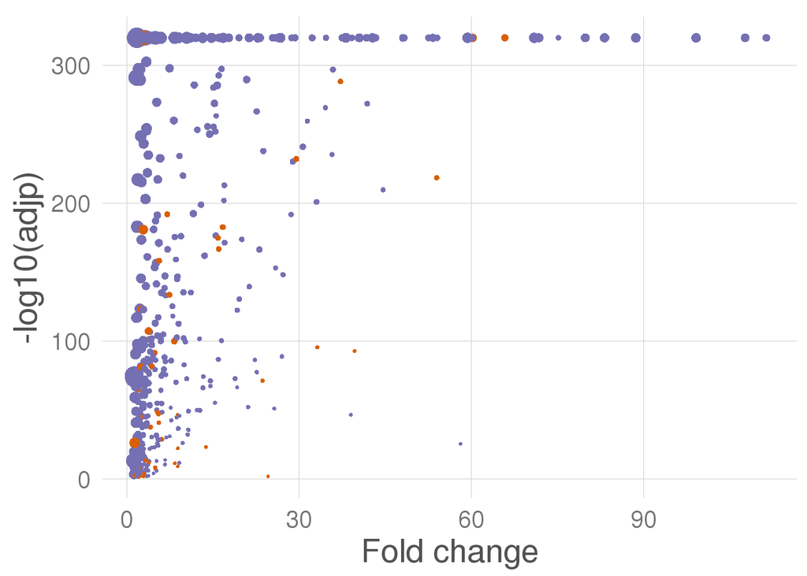

```r
feat_enrich <- read.delim(paste0(wd,'feature_enrichment.txt'), header=TRUE)

feat_enrich_agg <- ddply(feat_enrich,.(Domain), summarise,
                        MutIn=sum(MutIn), AllMuts=sum(AllMuts),
                        SwitchesIn=sum(SwitchesIn), AllSwitches=sum(AllSwitches),
                        DomainCount=sum(DomainCount),AllDomains=sum(AllDomains))
feat_enrich_agg$MutFreq <- feat_enrich_agg$MutIn/feat_enrich_agg$AllMuts
feat_enrich_agg$SwitchFreq <- feat_enrich_agg$SwitchesIn/feat_enrich_agg$AllSwitches
feat_enrich_agg$DomainFrequency <- feat_enrich_agg$DomainCount/feat_enrich_agg$AllDomains

feat_enrich_agg <- feat_enrich_agg[feat_enrich_agg$DomainFrequency!=0,]
feat_enrich_agg$FC <- feat_enrich_agg$SwitchFreq/feat_enrich_agg$DomainFrequency

feat_enrich_agg$p <- apply(feat_enrich_agg[,c("SwitchesIn","AllSwitches","DomainFrequency")],1, function(x){
  p <- binom.test(x[1],x[2],x[3],"greater")
  p$p.value
} )
feat_enrich_agg$adjp <- p.adjust(feat_enrich_agg$p)

# plot the significant features and the number of times they are gained or lost
# read candidates and features changed
candidatesDf_agg <- read.delim(paste0(wd,"candidateList_allCancers_models_notNoise.txt"))
structural_features <- read.delim(paste0(wd,"structural_features.onlyModels.tsv"))

# filterout non-changing features, and random results
nrStructural_features <- structural_features[structural_features$Random == "NonRandom",]
nrStructural_features <- nrStructural_features[nrStructural_features$WhatsHappenning != "Nothing",]

# merge with significantly changed features and with candidate info
nrStructural_features <- merge(nrStructural_features,subset(feat_enrich_agg, adjp < 0.05),by.x="Feature",by.y="Domain")
nrStructural_features <- merge(nrStructural_features,candidatesDf_agg,by.x=c("Gene","nTx","tTx"),by.y=c("GeneId","Normal_transcript","Tumor_transcript"))

# sum total instances of gain and loss
df <- ddply(nrStructural_features,.(Feature,FC,adjp),summarise,Losses=sum(PatientNumber*as.numeric(WhatsHappenning=="Lost_in_tumor")),Gains=sum(PatientNumber*as.numeric(WhatsHappenning=="Gained_in_tumor")))

# volcano plot
df.cp <- df
df.cp$adjp[df.cp$adjp == 0] <- 1e-320
df.cp$Sign <- ifelse(df.cp$Losses > df.cp$Gains, "Loss", "Gain")

ggplot(df.cp,aes(FC,-log10(adjp),color=Sign,size=sqrt(Losses+Gains))) +
  geom_point() +
  smartas_theme() +
  xlab("Fold change") +
  scale_color_manual(values=c("#d95f02","#7570b3"))
```

```r
# display stuff
df <- df[order(-df$FC),]
df$FC <- round(df$FC,2)
df$adjp <- format(df$adjp,digits=3)

df$Feature <- gsub("|"," - ",df$Feature,fixed = T)
df$Feature <- gsub("_"," ",df$Feature,fixed = T)

datatable(df)
```

|  | Feature | FC | adjp | Losses | Gains |
| --- | --- | --- | --- | --- | --- |
| 308 | PF13579 - Glycosyl transferase 4-like domain | 111.38 | 0.00e+00 | 3857 | 0 |
| 315 | PF13766 - 2-enoyl-CoA Hydratase C-terminal region | 107.7 | 0.00e+00 | 5608 | 0 |
| 304 | PF13476 - AAA domain | 99.15 | 0.00e+00 | 7650 | 0 |
| 333 | PF14962 - Mitochondria Localisation Sequence | 88.65 | 0.00e+00 | 7524 | 0 |
| 257 | PF11409 - Smad anchor for receptor activation (SARA) | 83.21 | 0.00e+00 | 7062 | 0 |
| 175 | PF05624 - Lipolysis stimulated receptor (LSR) | 83.14 | 0.00e+00 | 5693 | 0 |
| 272 | PF12162 - STAT1 TAZ2 binding domain | 79.84 | 0.00e+00 | 6160 | 0 |
| 163 | PF04721 - Domain of unknown function (DUF750) | 75.17 | 0.00e+00 | 1041 | 0 |
| 145 | PF03073 - TspO/MBR family | 71.76 | 0.00e+00 | 6644 | 0 |
| 173 | PF05586 - Anthrax receptor C-terminus region | 70.96 | 0.00e+00 | 9775 | 0 |

[output cut: 452 more lines]

The table above shows the features with an adjusted p-value of 0.05. Out of 5327 features affected by the switches, 462 of them (8.7%) are overrepresented. The median fold-change (frequency of the change/frequency of the domain) is quite high, of around 5. The Losses/Gains columns represent the number of times that feature is being gained in tumor or lost.

Some interesting things:

- [Lack of expression of SARA domain is related to EMT](http://www.ncbi.nlm.nih.gov/pubmed/19620243).
- Loss of Mitochondria Localisation Sequence is intriguing. What happens to those proteins?

```r
# create two groups
# Group 1: switches that gain/lose at least one of the significantly enriched domains
# Group 2: all the other switches
x <- unique(nrStructural_features[,c("Gene","nTx","tTx")])
colnames(x) <- c("GeneId","Normal_transcript","Tumor_transcript")
y <- candidatesDf_agg[! candidatesDf_agg$GeneId %in% x$GeneId &
                      ! candidatesDf_agg$Normal_transcript %in% x$Normal_transcript &
                      ! candidatesDf_agg$Tumor_transcript %in% x$Tumor_transcript &
                        as.logical(candidatesDf_agg$IsRelevant),
                      c("GeneId","Normal_transcript","Tumor_transcript")]

studyGroups(x,y,candidatesDf_agg)
```

```
## Size: group 1 -  1157 ; group 2 -  3420
## *relevance enrichment analysis
## cannot be performed because there are not enough different features.
## *CDS change enrichment analysis
## cannot be performed because there are not enough different features.
## *UTR change enrichment analysis
## Significant enrichment of 1 in Group 1 and of 0 in group 2 (p = 0; odds ratio = 0.54)
## *number of patients median difference test
## Significant difference. Group 1 higher than group 2 (57 vs. 30, p = 0)
## *drivers enrichment analysis
## Non significant enrichment of 1 in Group 1 and of 0 in group 2 (p = 0.1; odds ratio = 0.82)
## *oncogene enrichment analysis
## Non significant enrichment of No in Group 1 and of oncogene in group 2 (p = 1; odds ratio = 1)
## *oncogene/suppressor enrichment analysis
## Non significant enrichment of No in Group 1 and of oncogene/suppressor in group 2 (p = 0.2; odds ratio = Inf)
## *suppressor enrichment analysis
## Non significant enrichment of No in Group 1 and of suppressor in group 2 (p = 0.26; odds ratio = 1.44)
## *Unknown enrichment analysis
## Significant enrichment of Unknown in Group 1 and of No in group 2 (p = 0; odds ratio = 0.53)
## *d1 enrichment analysis
## Non significant enrichment of Nothing in Group 1 and of d1 in group 2 (p = 0.48; odds ratio = 1.06)
## *Driver enrichment analysis
## Non significant enrichment of Driver in Group 1 and of Nothing in group 2 (p = 0.14; odds ratio = 0.83)
## *hallmark enrichment analysis
## Non significant enrichment of No in Group 1 and of Hallmark in group 2 (p = 0.52; odds ratio = 0.95)
## *number of tumors median difference test
## Significant difference. Group 1 higher than group 2 (3 vs. 2, p = 0)
```

We created two sets of switches: the first one involves thea gain/loss of a domain significantly enriched; the second one involves any functional switch that does not involve it. We see how the switches that involve one of those domains tend to affect more patients and cancer types. Also there is a non-significant enrichment in driver genes in the first group.

```r
prosite_annotation <- read.delim(paste0(wd,"prosite2go.clean.txt"),row.names = NULL,header=F)
pfam_annotation <- read.delim(paste0(wd,"Pfam2go.clean.txt"),row.names = NULL,header=F)

annotation <- rbind(prosite_annotation,pfam_annotation)
colnames(annotation) <- c("id","annotation")

# remove the GO prefix from all of them
z <- gsub(";GO:[[:digit:]]+", "", annotation$annotation)
z <- gsub("^GO:", "", z)
z <- gsub("_", " ", z)
z <- paste0(toupper(substring(z, 1,1)),substring(z, 2))

annotation$GOid <- unlist(strsplit(as.character(annotation$annotation),";",fixed = T))[c(F,T)]
annotation$GO <- z

annotation <- annotation[,colnames(annotation) != "annotation"]

# annotate domains
df$id <- unlist(strsplit(df$Feature," - "))[c(T,F)]
df.go <- merge(df,annotation)

# annotation frequency
freqFunctions <- as.data.frame(table(df.go$GO))
colnames(freqFunctions) <- c("GO","Frequency")
freqFunctions <- freqFunctions[order(-freqFunctions$Frequency),]
row.names(freqFunctions) <- NULL

datatable(freqFunctions)
```

|  | GO | Frequency |
| --- | --- | --- |
| 1 | Protein binding | 38 |
| 2 | Zinc ion binding | 15 |
| 3 | ATP binding | 11 |
| 4 | Membrane | 11 |
| 5 | Integral component of membrane | 10 |
| 6 | Intracellular | 10 |
| 7 | Regulation of transcription, DNA-templated | 8 |
| 8 | Nucleic acid binding | 7 |
| 9 | Nucleus | 7 |
| 10 | Oxidation-reduction process | 7 |

[output cut: 149 more lines]

These functions are too generic right now to be really informative. It would be necessary to divide the different kinds of annotations (molecular function, cell compartment and biological process). However, from a first look it seems that there are several domains involved in transcription.

# Categorized analysis

```r
structural_features <- read.delim(paste0(wd,"structural_features.onlyModels.tsv"))
nrStructural_features <- structural_features[structural_features$Random == "NonRandom",]

for (featureType in c('Pfam','prosite')){

  annotation <- read.delim(paste0(workingDir,"/Data/Databases/",featureType,"2go.clean.txt"),row.names = NULL,header=F)
  colnames(annotation) <- c("id","GO")

  z <- gsub(";GO:[[:digit:]]+", "", annotation$GO)
  z <- gsub("^GO:", "", z)
  z <- paste0(toupper(substring(z, 1,1)),substring(z, 2))

  annotation$GO <- z

  for (action in c("Lost_in_tumor","Gained_in_tumor")){
    uniqStuff <- unique( nrStructural_features$Feature[nrStructural_features$Analysis==featureType & nrStructural_features$WhatsHappenning!="Nothing" & nrStructural_features$WhatsHappenning==action] )
    actionTag <- tolower(unlist(strsplit(action,split = " "))[1])

    for ( geneset in c("oncogene",'suppressor',"driver")){

      cat(paste(featureType,geneset,action,sep=" "))

      affectedFeats <- list()

      for (feat in uniqStuff){

        usedFeature <- nrStructural_features[nrStructural_features$WhatsHappenning==action & nrStructural_features$Feature==feat,]
        nonUsedFeature <- nrStructural_features[nrStructural_features$WhatsHappenning==action | nrStructural_features$Feature!=feat,]

        if (geneset=="driver"){
          FG=sum(usedFeature$Driver==1)
          FNG=sum(usedFeature$Driver==0)
          NFG=sum(nonUsedFeature$Driver==1)
          NFNG=sum(nonUsedFeature$Driver==0)
        } else {
          FG=sum(usedFeature$DriverType==geneset)
          FNG=sum(usedFeature$DriverType!=geneset)
          NFG=sum(nonUsedFeature$DriverType==geneset)
          NFNG=sum(nonUsedFeature$DriverType!=geneset)
        }

        affectedFeats[[feat]] <- data.frame(Feature=feat, WhatsHappenning=action,
                                            FG=FG,FNG=FNG,NFG=NFG,NFNG=NFNG)
      }

      affectedFeatsDf <- do.call('rbind',affectedFeats)

      affectedFeatsDf$p <- apply(affectedFeatsDf,1, function(x){
        k <- fisher.test(x=matrix(as.numeric(x[3:6]),nrow=2,ncol=2),alternative="greater")
        k$p.value } )
      affectedFeatsDf$p.adj <- p.adjust(affectedFeatsDf$p)
      affectedFeatsDf <- affectedFeatsDf[order(affectedFeatsDf$p),]
      kk <- merge(affectedFeatsDf,annotation,all.x=T)

      # prepare colums for print
      df <- affectedFeatsDf[,c("Feature","p","p.adj")]

      df$Feature <- gsub("|"," - ",df$Feature,fixed = T)
      df$Feature <- gsub("_"," ",df$Feature,fixed = T)

      df$p.adj <- format(df$p.adj,scientific=TRUE)
      df$p <- format(df$p,scientific=TRUE)

      print(kable(head(df,n=10),row.names=FALSE))

      write.table(affectedFeatsDf,file=paste(results_filepath,"tables",paste(featureType,actionTag,paste0(geneset,".tsv"),sep="_"),sep="/"),sep="\t", row.names=F, quote=F)

      # plot the significant groups
      affectedFeatsDf_s <- affectedFeatsDf[affectedFeatsDf$p.adj < 0.05,]

      if (nrow(affectedFeatsDf_s)==0){
        next
      }

      affectedFeatsDf_s$id <- unlist(strsplit(as.character(affectedFeatsDf_s$Feature),"|",fixed=T))[c(T,F)]
      affectedFeatsDf_s <- merge(affectedFeatsDf_s,annotation,all.x=T)

      annotationCount <- sort(table(as.character(affectedFeatsDf_s$GO)),decreasing=T)
      topGroups <- names(head(annotationCount[annotationCount > 1],4))

      plotAnnotatedFeats <- ddply(affectedFeatsDf_s,.(id,Feature,p.adj),function(y){
        x <- intersect(y$GO,topGroups)
        if (length(x) > 0){names(sort(-annotationCount[x])[1])} else {"Other"}})
      plotAnnotatedFeats$Annotation <- plotAnnotatedFeats$V1
      plotAnnotatedFeats$log_p <- -log10(plotAnnotatedFeats$p.adj)

      plotAnnotatedFeats <- plotAnnotatedFeats[order(-plotAnnotatedFeats$log_p,plotAnnotatedFeats$Feature),]
      plotAnnotatedFeats$Feature <- gsub("_"," ",unlist(strsplit(as.character(plotAnnotatedFeats$Feature),"|",fixed=T))[c(F,T)])

      plotAnnotatedFeats$Feature <- splitTextInLines(plotAnnotatedFeats$Feature)
      plotAnnotatedFeats$Feature <- factor(plotAnnotatedFeats$Feature,levels=as.factor(plotAnnotatedFeats$Feature))
      plotAnnotatedFeats$Annotation <- factor(plotAnnotatedFeats$Annotation,levels=as.factor(c(topGroups,"Other")))

      annotationPalette <- c("#d7191c","#fdae61","#ffffbf","#abdda4","#2b83ba")
      names(annotationPalette) <- c(topGroups,"Other")

      p <- ggplot(plotAnnotatedFeats,aes(x=Feature,y=log_p,fill=Annotation)) +
        geom_bar(stat="identity",position="dodge") +
        smartas_theme() +
        scale_fill_manual(values=annotationPalette) +
        xlab(paste0(featureType," features")) + ylab("-log10(adjusted p)") +
        facet_wrap(~Annotation,drop=TRUE,scale="free_x") +
        theme(axis.text.x=element_text(size=7,angle=90,hjust=1,vjust=0.5,colour="black"))
      ggsave(paste0(results_filepath,"figures/",paste(featureType,actionTag,paste0(geneset,".png"),sep="_")),p)

      print(p)

    }
  }
}
```

Pfam oncogene Lost_in_tumor

| Feature | p | p.adj |
| --- | --- | --- |
| PF12763 - Cytoskeletal-regulatory complex EF hand | 1.922556e-22 | 1.168914e-19 |
| PF02198 - Sterile alpha motif (SAM)/Pointed domain | 5.767938e-11 | 3.501138e-08 |
| PF01429 - Methyl-CpG binding domain | 2.045640e-09 | 1.239658e-06 |
| PF00134 - Cyclin, N-terminal domain | 1.335939e-08 | 8.082433e-06 |
| PF00856 - SET domain | 1.388636e-08 | 8.387363e-06 |
| PF05033 - Pre-SET motif | 5.380757e-08 | 3.244597e-05 |
| PF11467 - Lens epithelium-derived growth factor (LEDGF) | 5.735808e-08 | 3.452956e-05 |
| PF00514 - Armadillo/beta-catenin-like repeat | 1.590244e-06 | 9.557369e-04 |
| PF12403 - Paired-box protein 2 C terminal | 1.609384e-06 | 9.656302e-04 |
| PF01030 - Receptor L domain | 4.506708e-05 | 2.699518e-02 |

Pfam suppressor Lost_in_tumor

| Feature | p | p.adj |
| --- | --- | --- |
| PF00400 - WD domain, G-beta repeat | 1.902846e-15 | 1.156931e-12 |
| PF13589 - Histidine kinase-, DNA gyrase B-, and HSP90-like ATPase | 5.757516e-15 | 3.494812e-12 |
| PF13465 - Zinc-finger double domain | 5.975459e-14 | 3.621128e-11 |
| PF00531 - Death domain | 7.811580e-09 | 4.726006e-06 |
| PF00620 - RhoGAP domain | 8.790717e-06 | 5.309593e-03 |
| PF01119 - DNA mismatch repair protein, C-terminal domain | 1.678449e-04 | 1.012105e-01 |
| PF09379 - FERM N-terminal domain | 2.503381e-04 | 1.507036e-01 |
| PF07653 - Variant SH3 domain | 1.238091e-02 | 1.000000e+00 |
| PF08563 - P53 transactivation motif | 1.304144e-02 | 1.000000e+00 |
| PF13716 - Divergent CRAL/TRIO domain | 1.304144e-02 | 1.000000e+00 |

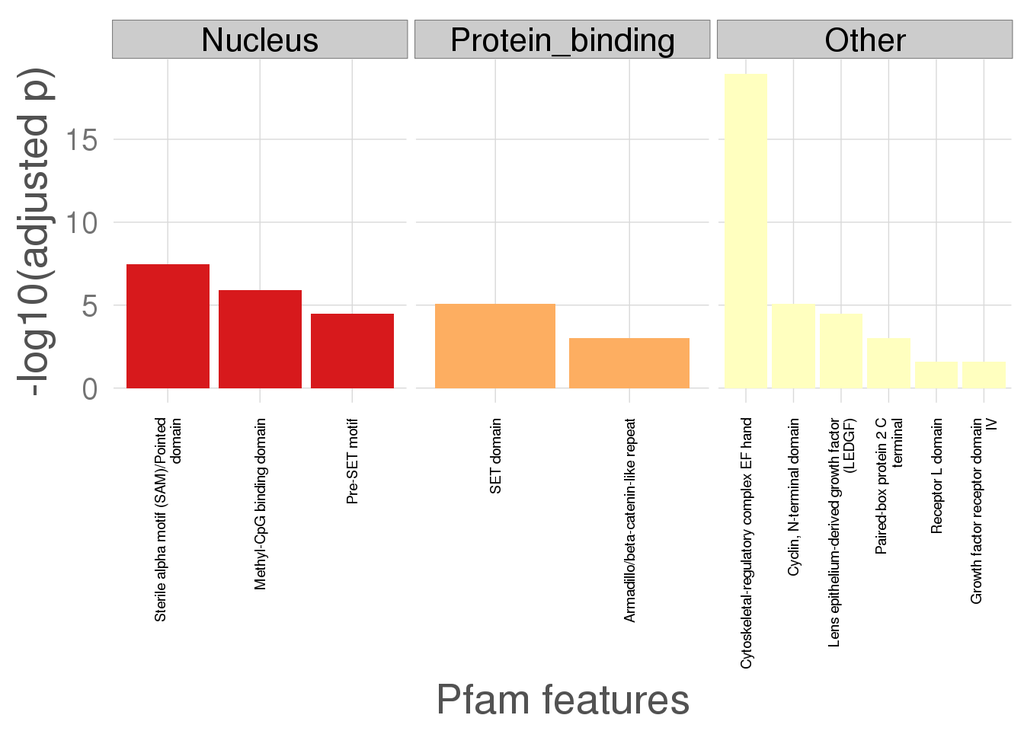

Pfam driver Lost_in_tumor

| Feature | p | p.adj |
| --- | --- | --- |
| PF13589 - Histidine kinase-, DNA gyrase B-, and HSP90-like ATPase | 6.318037e-20 | 3.841367e-17 |
| PF12763 - Cytoskeletal-regulatory complex EF hand | 1.003327e-16 | 6.090195e-14 |
| PF01335 - Death effector domain | 2.132922e-11 | 1.292550e-08 |
| PF01044 - Vinculin family | 2.132922e-11 | 1.292550e-08 |
| PF00319 - SRF-type transcription factor (DNA-binding and dimerisation domain) | 2.153931e-11 | 1.300974e-08 |
| PF00452 - Apoptosis regulator proteins, Bcl-2 family | 1.208515e-09 | 7.287344e-07 |
| PF00105 - Zinc finger, C4 type (two domains) | 1.173474e-08 | 7.064313e-06 |
| PF13465 - Zinc-finger double domain | 3.872583e-07 | 2.327422e-04 |
| PF01429 - Methyl-CpG binding domain | 3.975034e-07 | 2.385021e-04 |
| PF00605 - Interferon regulatory factor transcription factor | 3.975837e-07 | 2.385021e-04 |

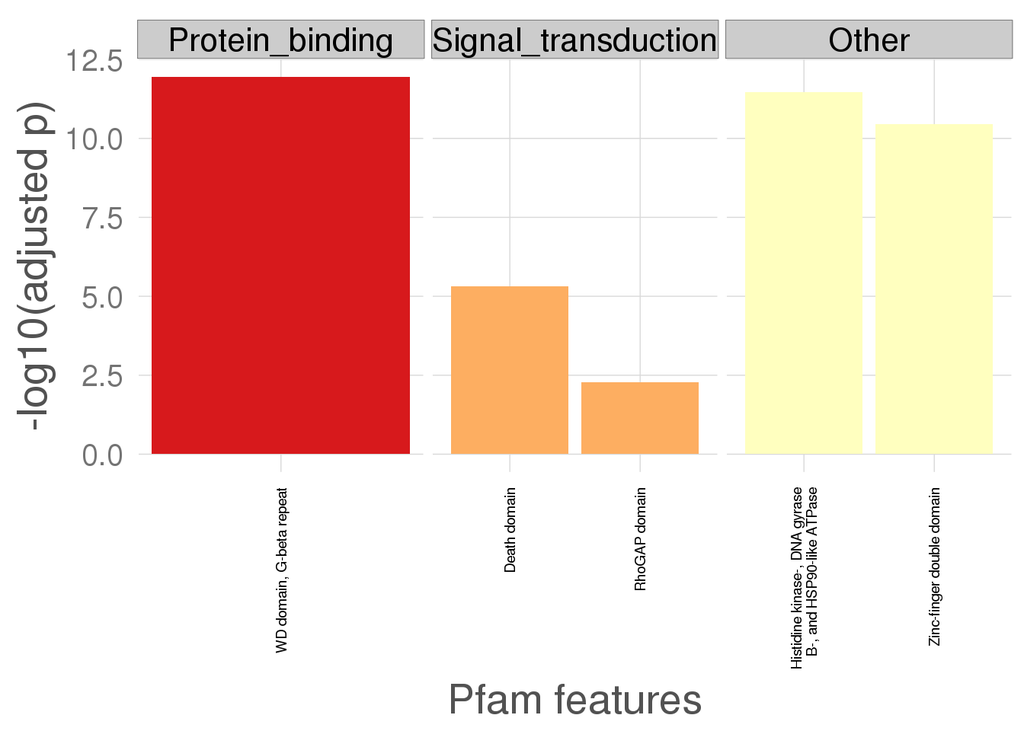

Pfam oncogene Gained_in_tumor

| Feature | p | p.adj |
| --- | --- | --- |
| PF03826 - OAR domain | 5.735808e-08 | 1.072596e-05 |
| PF13465 - Zinc-finger double domain | 7.830197e-07 | 1.456417e-04 |
| PF00071 - Ras family | 2.919204e-06 | 5.400528e-04 |
| PF00168 - C2 domain | 2.282592e-05 | 4.199970e-03 |
| PF00017 - SH2 domain | 1.031300e-01 | 1.000000e+00 |
| PF00096 - Zinc finger, C2H2 type | 2.230354e-01 | 1.000000e+00 |
| PF13499 - EF-hand domain pair | 1.000000e+00 | 1.000000e+00 |
| PF01391 - Collagen triple helix repeat (20 copies) | 1.000000e+00 | 1.000000e+00 |
| PF00400 - WD domain, G-beta repeat | 1.000000e+00 | 1.000000e+00 |
| PF07679 - Immunoglobulin I-set domain | 1.000000e+00 | 1.000000e+00 |

[figure not shown]

Pfam suppressor Gained_in_tumor

| Feature | p | p.adj |
| --- | --- | --- |
| PF00400 - WD domain, G-beta repeat | 8.260716e-10 | 1.544754e-07 |
| PF00041 - Fibronectin type III domain | 4.226900e-05 | 7.862034e-03 |
| PF00620 - RhoGAP domain | 1.301698e-02 | 1.000000e+00 |
| PF07653 - Variant SH3 domain | 2.586794e-02 | 1.000000e+00 |
| PF00307 - Calponin homology (CH) domain | 2.589903e-02 | 1.000000e+00 |
| PF13499 - EF-hand domain pair | 1.000000e+00 | 1.000000e+00 |
| PF01391 - Collagen triple helix repeat (20 copies) | 1.000000e+00 | 1.000000e+00 |
| PF07679 - Immunoglobulin I-set domain | 1.000000e+00 | 1.000000e+00 |
| PF00084 - Sushi domain (SCR repeat) | 1.000000e+00 | 1.000000e+00 |
| PF00038 - Intermediate filament protein | 1.000000e+00 | 1.000000e+00 |

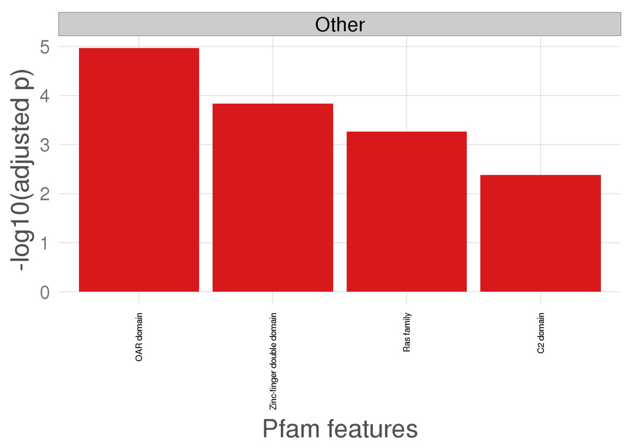

Pfam driver Gained_in_tumor

| Feature | p | p.adj |
| --- | --- | --- |
| PF02376 - CUT domain | 6.351538e-20 | 1.187738e-17 |
| PF00046 - Homeobox domain | 3.966132e-07 | 7.377005e-05 |
| PF03826 - OAR domain | 4.635367e-06 | 8.575428e-04 |
| PF13465 - Zinc-finger double domain | 1.238728e-04 | 2.279260e-02 |
| PF00071 - Ras family | 2.076055e-04 | 3.799180e-02 |
| PF00017 - SH2 domain | 6.277352e-04 | 1.142478e-01 |
| PF00168 - C2 domain | 7.046987e-04 | 1.275505e-01 |
| PF00856 - SET domain | 7.333978e-03 | 1.000000e+00 |
| PF00855 - PWWP domain | 7.340233e-03 | 1.000000e+00 |
| PF13855 - Leucine rich repeat | 7.341218e-03 | 1.000000e+00 |

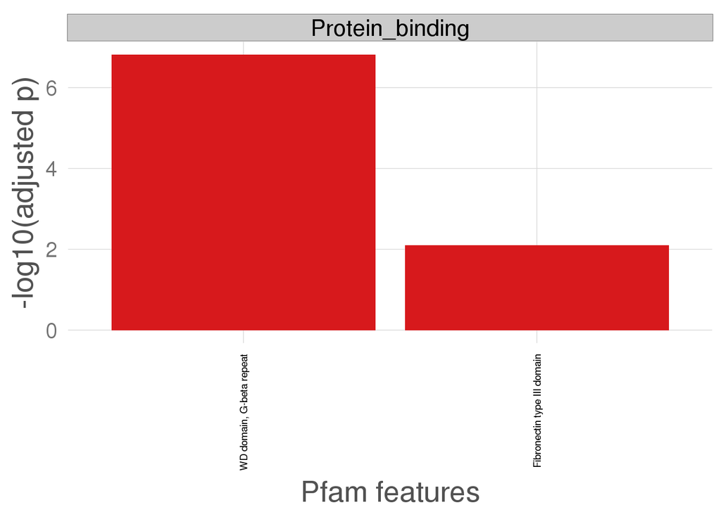

prosite oncogene Lost_in_tumor

| Feature | p | p.adj |
| --- | --- | --- |
| PS50031 - EH EH domain profile. | 1.922556e-22 | 4.248849e-20 |
| PS50222 - EF HAND 2 EF-hand calcium-binding domain profile. | 3.392789e-14 | 7.464136e-12 |
| PS50322 - GLN RICH Glutamine-rich region profile. | 4.317351e-11 | 9.454998e-09 |
| PS51433 - PNT Pointed (PNT) domain profile. | 5.767938e-11 | 1.257410e-08 |
| PS50157 - ZINC FINGER C2H2 2 Zinc finger C2H2 type domain profile. | 5.996366e-05 | 1.301212e-02 |
| PS51030 - NUCLEAR REC DBD 2 Nuclear hormone receptors DNA-binding domain profile. | 2.923591e-04 | 6.314957e-02 |
| PS50217 - BZIP Basic-leucine zipper (bZIP) domain profile. | 3.328842e-04 | 7.157011e-02 |
| PS50231 - RICIN B LECTIN Lectin domain of ricin B chain profile. | 1.267353e-03 | 2.712134e-01 |
| PS50835 - IG LIKE Ig-like domain profile. | 4.387080e-03 | 9.344479e-01 |
| PS51162 - THYROGLOBULIN 1 2 Thyroglobulin type-1 domain profile. | 7.251385e-03 | 1.000000e+00 |

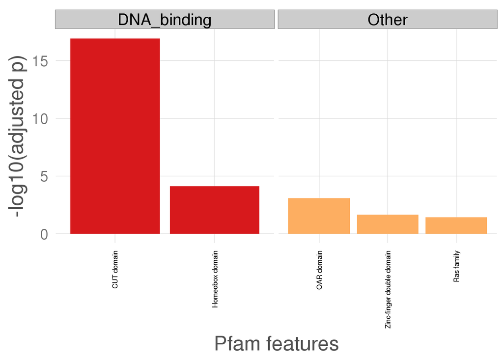

prosite suppressor Lost_in_tumor

| Feature | p | p.adj |
| --- | --- | --- |
| PS50017 - DEATH DOMAIN Death domain profile. | 2.255554e-09 | 4.984774e-07 |
| PS50238 - RHOGAP Rho GTPase-activating proteins domain profile. | 2.219361e-06 | 4.882594e-04 |
| PS50294 - WD REPEATS REGION Trp-Asp (WD) repeats circular profile. | 2.912232e-05 | 6.377789e-03 |
| PS50002 - SH3 Src homology 3 (SH3) domain profile. | 3.048235e-02 | 1.000000e+00 |
| PS50082 - WD REPEATS 2 Trp-Asp (WD) repeats profile. | 4.694929e-02 | 1.000000e+00 |
| PS50006 - FHA DOMAIN Forkhead-associated (FHA) domain profile. | 5.115344e-02 | 1.000000e+00 |
| PS50021 - CH Calponin homology domain profile. | 8.773481e-02 | 1.000000e+00 |
| PS50157 - ZINC FINGER C2H2 2 Zinc finger C2H2 type domain profile. | 7.990057e-01 | 1.000000e+00 |
| PS50099 - PRO RICH Proline-rich region profile. | 8.871999e-01 | 1.000000e+00 |
| PS50194 - FILAMIN REPEAT Filamin/ABP280 repeat profile. | 1.000000e+00 | 1.000000e+00 |

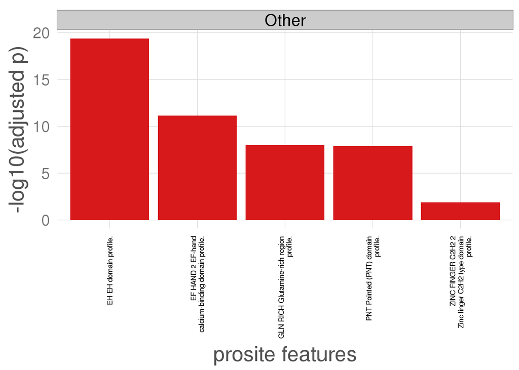

prosite driver Lost_in_tumor

| Feature | p | p.adj |
| --- | --- | --- |
| PS50031 - EH EH domain profile. | 1.003327e-16 | 2.217353e-14 |
| PS50168 - DED Death effector domain (DED) profile. | 2.132922e-11 | 4.692427e-09 |
| PS50066 - MADS BOX 2 MADS-box domain profile. | 2.153931e-11 | 4.717109e-09 |
| PS50208 - CASPASE P20 Caspase family p20 domain profile. | 2.172976e-10 | 4.737088e-08 |
| PS50222 - EF HAND 2 EF-hand calcium-binding domain profile. | 7.996895e-09 | 1.735326e-06 |
| PS51030 - NUCLEAR REC DBD 2 Nuclear hormone receptors DNA-binding domain profile. | 1.904079e-08 | 4.112811e-06 |
| PS51507 - IRF 2 IRF tryptophan pentad repeat DNA-binding domain profile. | 3.976714e-07 | 8.549935e-05 |
| PS50001 - SH2 Src homology 2 (SH2) domain profile. | 4.681842e-07 | 1.001914e-04 |
| PS51433 - PNT Pointed (PNT) domain profile. | 5.304655e-07 | 1.129891e-04 |
| PS50322 - GLN RICH Glutamine-rich region profile. | 7.890956e-07 | 1.672883e-04 |

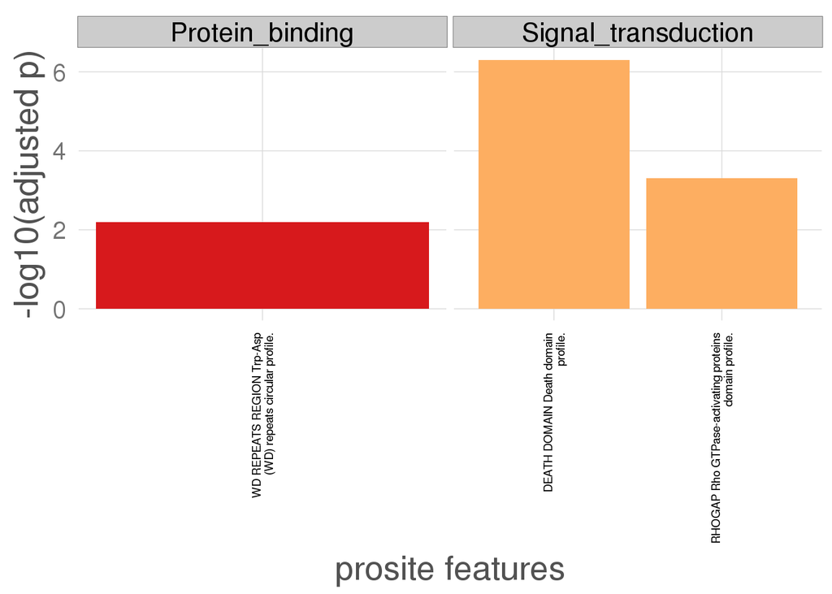

prosite oncogene Gained_in_tumor

| Feature | p | p.adj |
| --- | --- | --- |
| PS50803 - OAR OAR domain profile. | 5.735808e-08 | 5.563734e-06 |
| PS50004 - C2 C2 domain profile. | 2.281187e-05 | 2.189939e-03 |
| PS50157 - ZINC FINGER C2H2 2 Zinc finger C2H2 type domain profile. | 3.424125e-05 | 3.252919e-03 |
| PS50231 - RICIN B LECTIN Lectin domain of ricin B chain profile. | 3.558660e-02 | 1.000000e+00 |
| PS50311 - CYS RICH Cysteine-rich region profile. | 3.564265e-02 | 1.000000e+00 |
| PS50001 - SH2 Src homology 2 (SH2) domain profile. | 1.030916e-01 | 1.000000e+00 |
| PS50322 - GLN RICH Glutamine-rich region profile. | 1.952938e-01 | 1.000000e+00 |
| PS50099 - PRO RICH Proline-rich region profile. | 5.462992e-01 | 1.000000e+00 |
| PS50222 - EF HAND 2 EF-hand calcium-binding domain profile. | 1.000000e+00 | 1.000000e+00 |
| PS50324 - SER RICH Serine-rich region profile. | 1.000000e+00 | 1.000000e+00 |

[figure not shown]

prosite suppressor Gained_in_tumor

| Feature | p | p.adj |
| --- | --- | --- |
| PS50021 - CH Calponin homology domain profile. | 2.589620e-02 | 1e+00 |
| PS50238 - RHOGAP Rho GTPase-activating proteins domain profile. | 3.854307e-02 | 1e+00 |
| PS50002 - SH3 Src homology 3 (SH3) domain profile. | 9.949712e-02 | 1e+00 |
| PS50222 - EF HAND 2 EF-hand calcium-binding domain profile. | 1.000000e+00 | 1e+00 |
| PS50324 - SER RICH Serine-rich region profile. | 1.000000e+00 | 1e+00 |
| PS50099 - PRO RICH Proline-rich region profile. | 1.000000e+00 | 1e+00 |
| PS50322 - GLN RICH Glutamine-rich region profile. | 1.000000e+00 | 1e+00 |
| PS50316 - HIS RICH Histidine-rich region profile. | 1.000000e+00 | 1e+00 |
| PS50082 - WD REPEATS 2 Trp-Asp (WD) repeats profile. | 1.000000e+00 | 1e+00 |
| PS50835 - IG LIKE Ig-like domain profile. | 1.000000e+00 | 1e+00 |
| prosite driver Gained_in_tumor |  |  |

| Feature | p | p.adj |
| --- | --- | --- |
| PS50803 - OAR OAR domain profile. | 4.635367e-06 | 4.496306e-04 |
| PS50600 - ULP PROTEASE Ubiquitin-like protease family profile. | 5.404832e-05 | 5.188638e-03 |
| PS50001 - SH2 Src homology 2 (SH2) domain profile. | 6.270081e-04 | 5.956577e-02 |
| PS50004 - C2 C2 domain profile. | 7.042744e-04 | 6.620180e-02 |
| PS50157 - ZINC FINGER C2H2 2 Zinc finger C2H2 type domain profile. | 4.062597e-03 | 3.778215e-01 |
| PS50002 - SH3 Src homology 3 (SH3) domain profile. | 2.543224e-02 | 1.000000e+00 |
| PS50119 - ZF BBOX Zinc finger B-box type profile. | 8.561786e-02 | 1.000000e+00 |
| PS50231 - RICIN B LECTIN Lectin domain of ricin B chain profile. | 8.571297e-02 | 1.000000e+00 |
| PS50089 - ZF RING 2 Zinc finger RING-type profile. | 8.571849e-02 | 1.000000e+00 |
| PS50311 - CYS RICH Cysteine-rich region profile. | 8.573006e-02 | 1.000000e+00 |

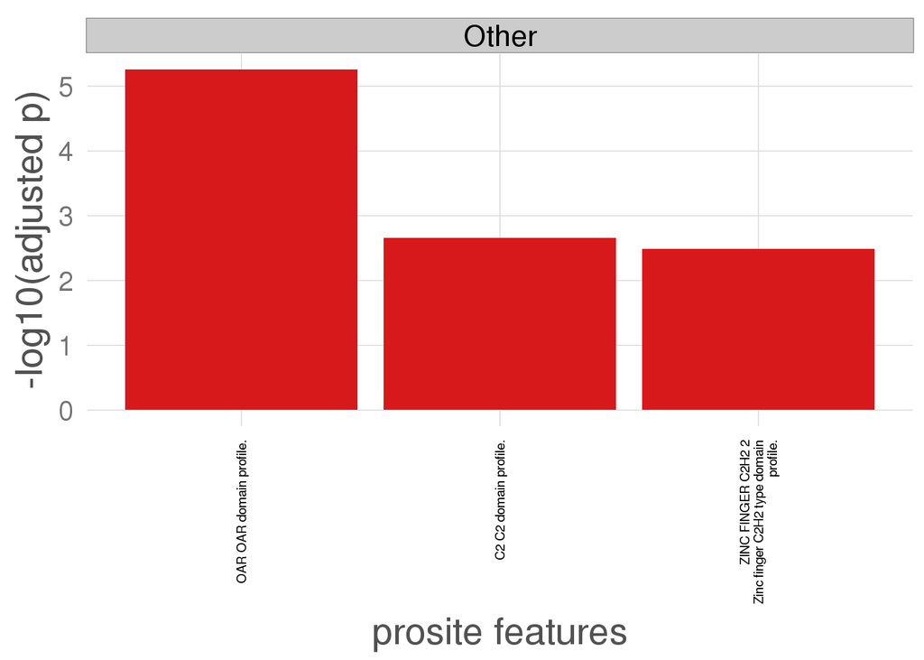

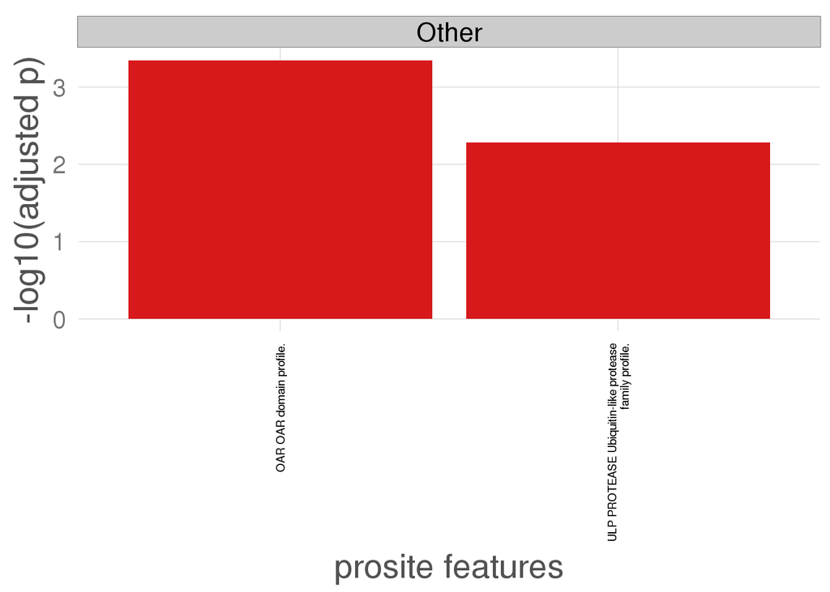